Udruga zlatnih maslinara Pakoštane

# Zlatna maslinova ulja iz Pakoštana

Okupljamo lokalne maslinare koji redovito osvajaju prestižna svjetska priznanja za vrhunska maslinova ulja.

Upoznajte maslinare

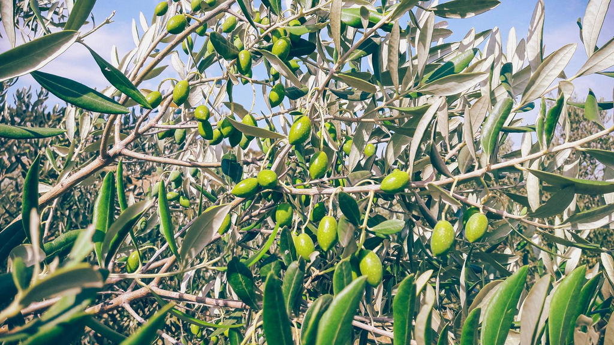

Svjetska priznanja

Zlatne medalje s natjecanja u New Yorku, Berlinu i Londonu.

## Predstavljanje

O nama

Maslinari koji čuvaju tradiciju i osvajaju svijet

Udruga zlatnih maslinara Pakoštane okuplja lokalne maslinare i brine o tome da pakoštanska ulja budu prepoznata po kvaliteti.

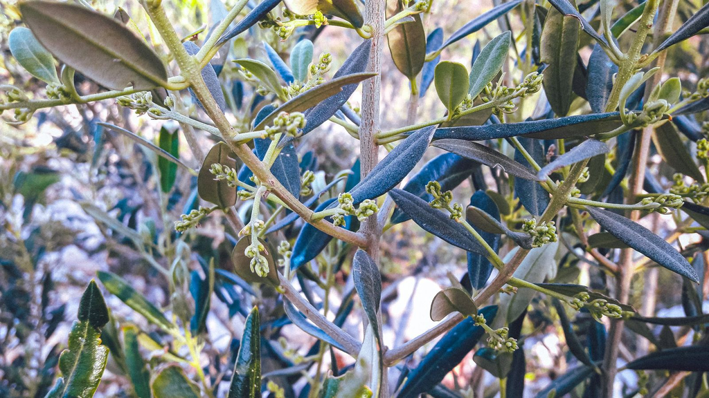

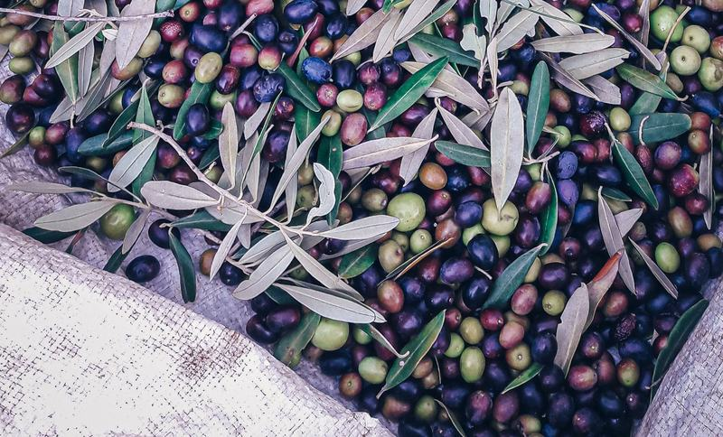

### Priča o udruzi

**Misija.** Okupljati pakoštanske maslinare, čuvati tradiciju maslinarstva i promovirati vrhunska maslinova ulja ovog kraja.

**Vizija.** Pakoštane kao prepoznata destinacija zlatnih maslinovih ulja, s maslinarima koji znanje prenose na mlađe naraštaje.

Postanite član

### Kvaliteta i nagrade

Zlatna ulja Pakoštana: autohtone sorte, pažljiva prerada i brand koji se prepoznaje na međunarodnim natjecanjima.

01

#### Svjetske nagrade

02

#### Pakoško zlato

Naša manifestacija slavi ekstradjevička maslinova ulja uz degustacije, gostovanja kuhara i dalmatinsku feštu.

03

#### Edukacija mladih

S Osnovnom školom Pakoštane i Turističkom zajednicom općine Pakoštane provodimo radionice o rezidbi i uzgoju maslina za najmlađe.

### Tijela udruge

Osnovne informacije o vodstvu i organizaciji udruge.

## Pojedinci

Članovi udruge

Maslinari i OPG-ovi koji čine udrugu. Na stranicama svakog od njih možete doznati više o ulju i kupiti ga izravno.

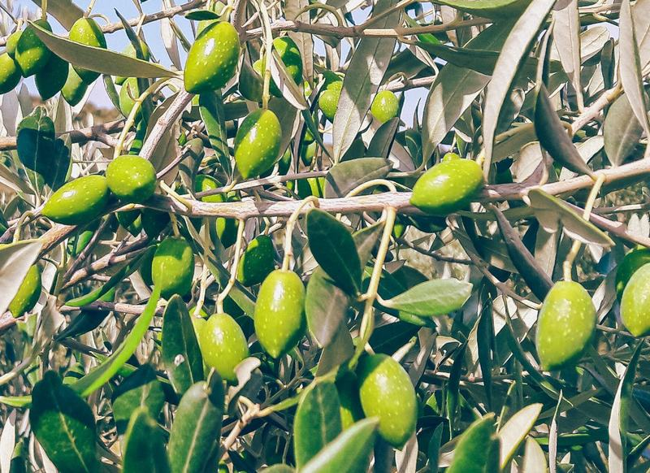

OPG

### OPG Leut

Posjetite stranicu

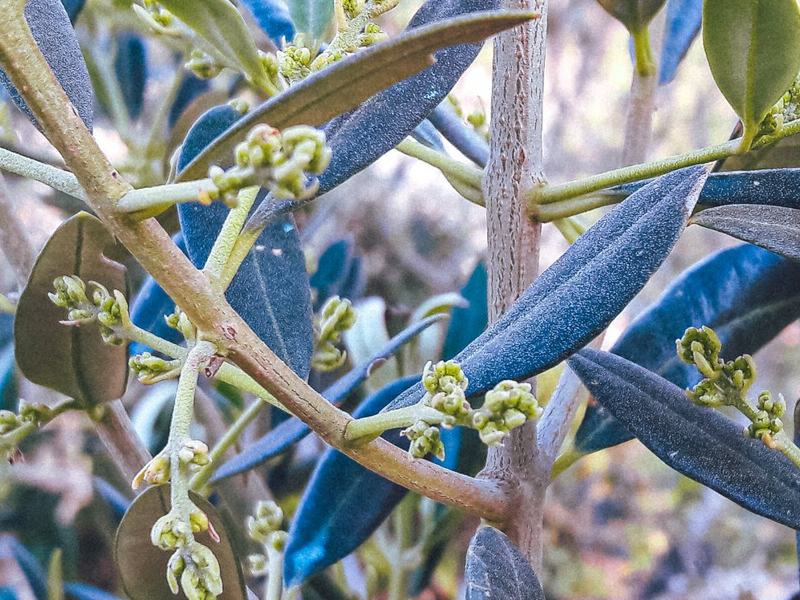

OPG

### OPG Didini vrtovi

Posjetite stranicu

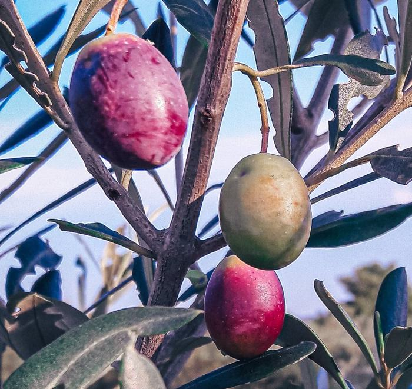

Obrt

### Obrt Skipper

Posjetite stranicu

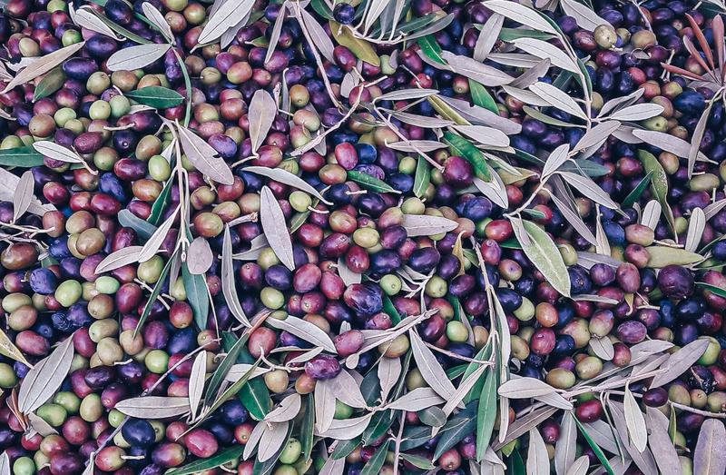

OPG

### OPG Čelini

Posjetite stranicu

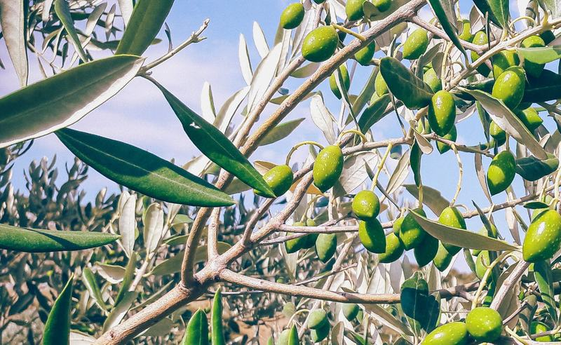

OPG

### OPG Ćaće moga

Posjetite stranicu

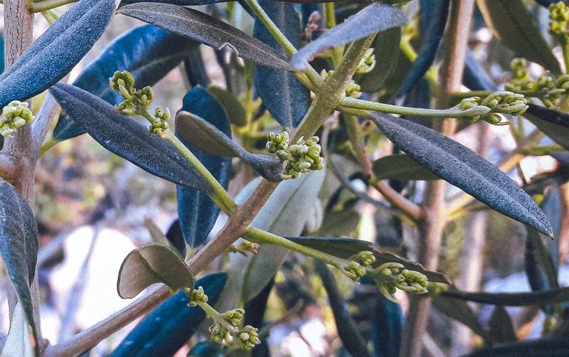

OPG

### OPG Ante Vulin

Posjetite stranicu

## Galerija

Naš rad

Kadrovi iz maslinika, s manifestacija i iz pakoštanskog krajolika.

### Rad u masliniku, berba i prerada

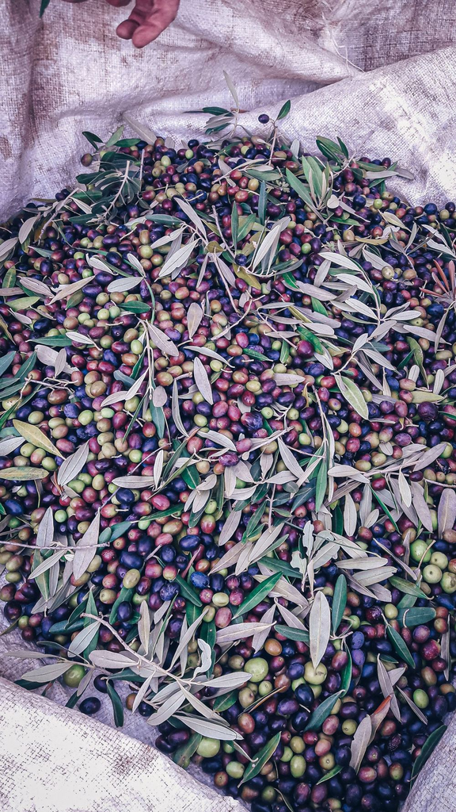

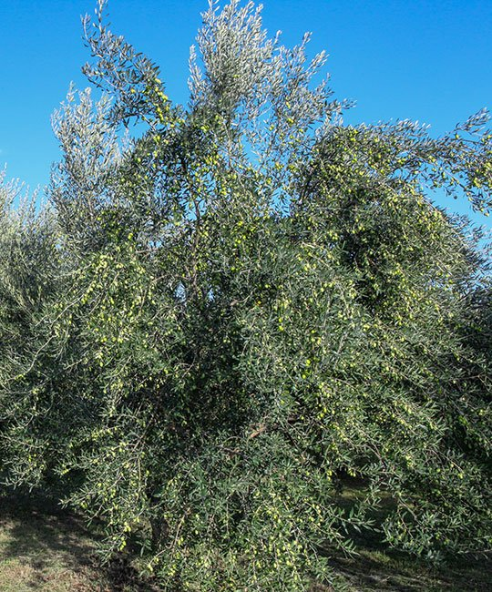

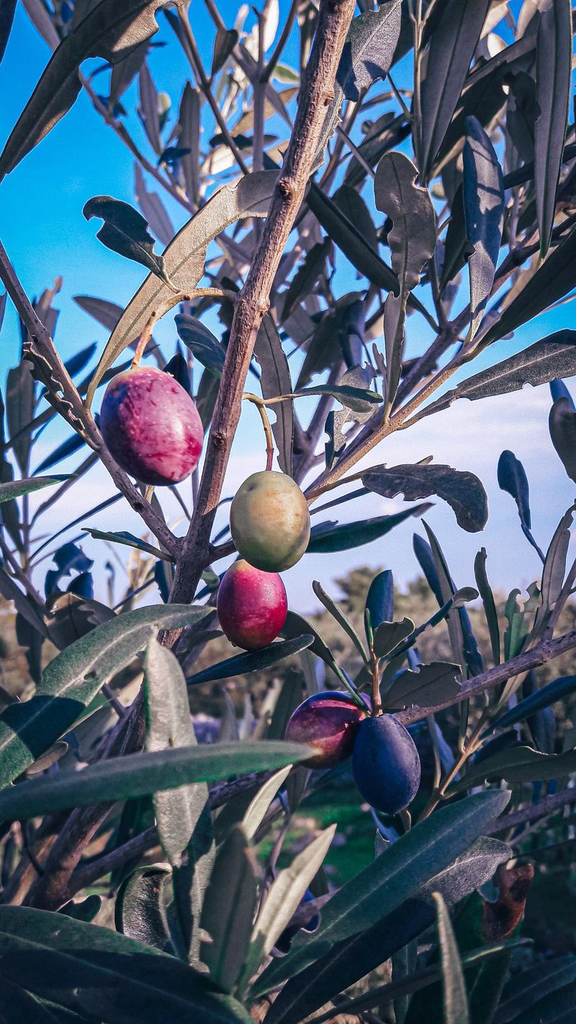

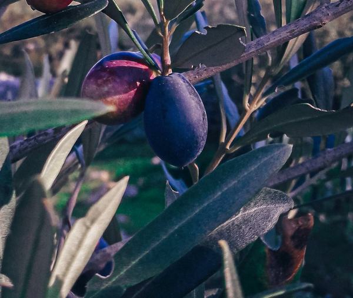

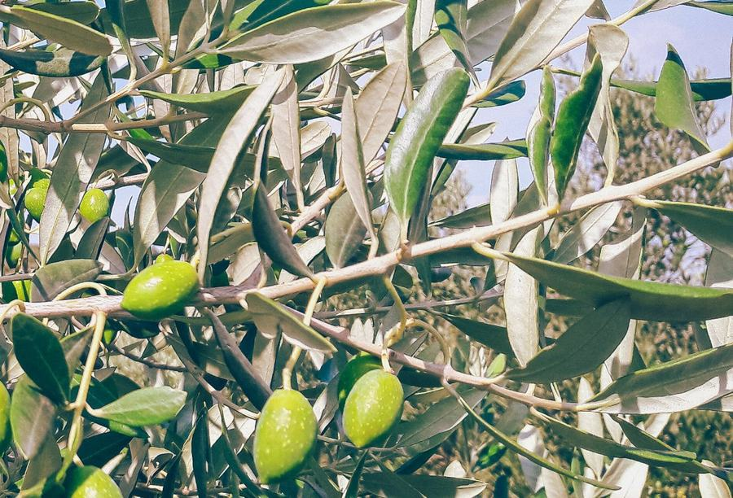

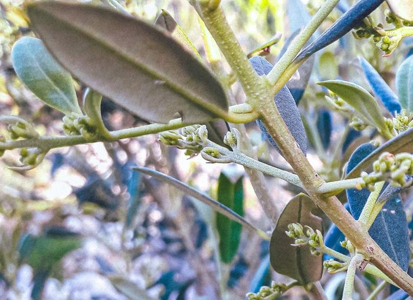

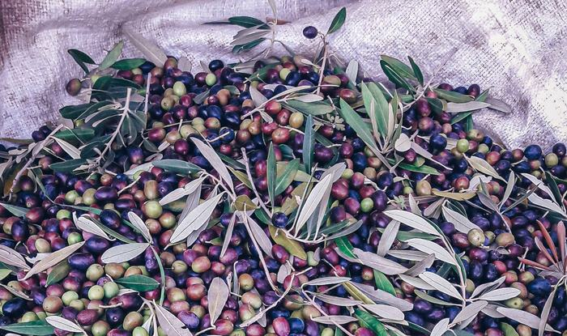

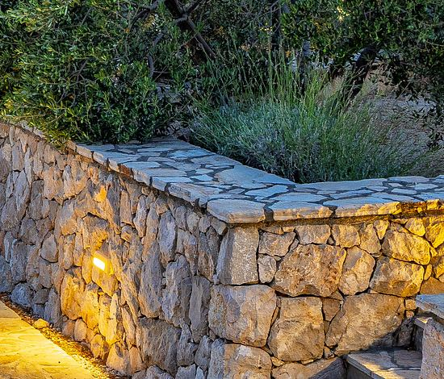

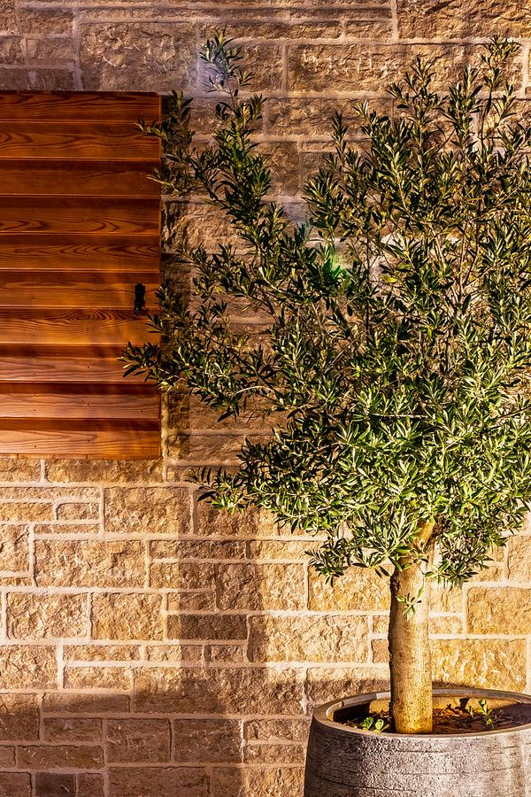

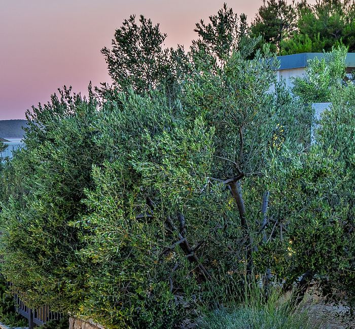

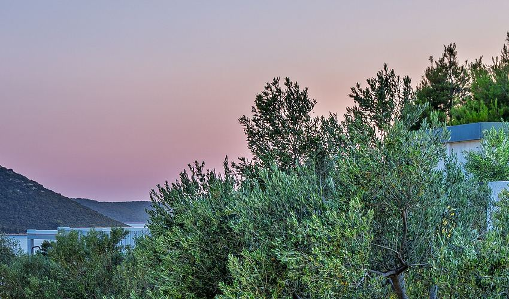

## Aktualno

Novosti

Novosti iz udruge, najave događanja i video zapisi. Objave uređuje sama udruga.

Video

### Pakoško zlato

Degustacije ekstradjevičanskih ulja, kuhari i dalmatinska fešta na našoj manifestaciji.

### Djeca uče prve korake maslinarstva

Radionice o rezidbi i uzgoju maslina s učenicima Osnovne škole Pakoštane.

### Nove zlatne medalje za pakoštanska ulja

Pregled priznanja koja su naši članovi osvojili na međunarodnim natjecanjima.

## Kontakt

Javite se

### Pošaljite upit

Pitanja o udruzi, ulju ili članstvu. Odgovaramo na e-mail ili telefon koji ostavite.

Ime i prezime

E-mail

Telefon

Tema

Poruka

Slanjem obrasca dajem privolu da se moji podaci koriste isključivo za odgovor na ovaj upit, u skladu s izjavom o privatnosti.

Hvala na upitu. Ovo je prototip, poruka nije poslana.

Naziv udruge

Udruga zlatnih maslinara Pakoštane

Adresa sjedišta

Ul. Kraljice Jelene 78  
23211 Pakoštane

OIB

75598583532

### Postanite član Udruge zlatnih maslinara

Preuzmite pristupnicu